# 网络科学以及PageRank算法

# PageRank算法

## 1. 算法来源

## 2. 算法原理

## 3. 算法实现

## 4. 算法演示

# 算法来源

这个要从搜索引擎的发展讲起。最早的搜索引擎采用的是 分类目录的方法，即通过人工进行网页分类并整理出高质量的网站。那时 Yahoo 和国内的 hao123 就是使用的这种方法。 后来网页越来越多，人工分类已经不现实了。搜索引擎进入了文本检索的时代，即计算用户查询关键词与网页内容的相关程度来返回搜索结果。这种方法突破了数量的限制，但是搜索结果不是很好。因为总有某些网页来回地倒腾某些关键词使自己的搜索排名靠前。 后来，谷歌的两位创始人，佩奇 (Larry Page) 和布林 (Sergey Brin) 开始了对网页排序问题的研究。他们的借鉴了学术界评判学术论文重要性的通用方法，那就是看论文的引用次数。由此想到网页的重要性也可以根据这种方法来评价。于是PageRank的核心思想就诞生了，非常简单：

**如果一个网页被很多其他网页链接到的话说明这个网页比较重要，也就是PageRank值会相对较高**

**如果一个PageRank值很高的网页链接到一个其他的网页，那么被链接到的网页的PageRank值会相应地因此而提高**

# 算法原理

$PageRank$算法总的来说就是预先给每个网页一个$PR$值，由于$PR$值物理意义上为一个网页被访问概率，所以一般是$\frac1N$, 其中$N$为网页总数。另外，一般情况下，所有网页的$PR$值的总和为1。如果不为1的话也不是不行，最后算出来的不同网页之间$PR$值的大小关系仍然是正确的，只是不能直接地反映概率了。

预先给定$PR$值后，通过下面的算法不断迭代，直至达到平稳分布为止。

互联网中的众多网页可以看作一个有向图。下图是一个简单的例子：

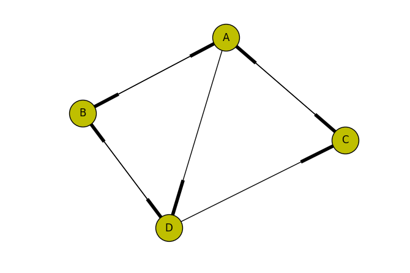

```python
import networkx as nx
import matplotlib.pyplot as plt
G = nx.DiGraph()
G.add_edges_from([('A', 'C'), ('A', 'B'), ('A', 'D'),('B', 'A'), ('B', 'D'), ('C', 'A'), ('D', 'B'), ('D', 'C')])
nx.draw(G,pos=nx.fruchterman_reingold_layout(G), with_labels=True, node_size = 1000, node_color = 'y')
plt.show()
```